# anagram

2024-05-15

## Загрузка пакетов

```r
library(tidyverse)
library(dplyr)
library(Hmisc)
library(readxl)
```

## Загрузка ответов

```r
responses <- NULL
for (item in 1:10) {
  if(is.null(responses)) {
    responses <- read_excel("data/responses/Ответы респондентов.xlsx", sheet = item)
    next
  }
  responses <- bind_rows(responses, read_excel("data/responses/Ответы респондентов.xlsx", sheet = item))
}
```

## Загрузка данных 1 этапа

```r
# первый
data_path <- 'data/1_part/'
load_file_1 <- function(x) {
  if (str_detect(x, 'csv')) {
    df <- read_csv(str_c(data_path, x),
                   col_types = cols(.default = col_character()))

    info <- str_replace(x, "Run_", "")
    info <- str_replace(info, ".csv", "")
    df$info <- info
    info <- str_split(info, "-")
    info <- info %>% unlist()

    df$block <- info[1] %>% as.factor()
    df$user_id <- info[2] %>% as.factor()
    df$sequence <- info[3] %>% as.factor()

    df$prob <- 0
    # добавление порядкого номера
    df[!is.na(df$ProbesList), 'prob'] <- 1:26
    block <- unlist(gregexpr(info[1], info[3]))
    block <- 26 * (block -1 )
    df$prob <- df$prob + block
    df[is.na(df$ProbesList), 'prob'] <- 0
    df$Target.RT <- df$Target.RT %>% as.numeric()
    df$Subject <- df$user_id
    return(df)

  }
}

part_1 <- do.call('bind_rows',
                 data_path %>%
                   list.files() %>%
                   lapply(load_file_1)
)
part_1 %>% View()

part_1 <- part_1 %>% filter(!is.na(ProbesList))
```

Проверка, что количество проб равное на всех словах

```r
part_1$ProbesList %>% table()
```

```
## .
##  1 10 11 12 13 14 15 16 17 18 19  2 20 21 22 23 24 25 26  3  4  5  6  7  8  9
## 30 30 30 30 30 30 30 30 30 30 30 30 30 30 30 30 30 30 30 30 30 30 30 30 30 30
```

```r
part_1$prob %>% table()
```

```
## .
##  1  2  3  4  5  6  7  8  9 10 11 12 13 14 15 16 17 18 19 20 21 22 23 24 25 26
## 10 10 10 10 10 10 10 10 10 10 10 10 10 10 10 10 10 10 10 10 10 10 10 10 10 10
## 27 28 29 30 31 32 33 34 35 36 37 38 39 40 41 42 43 44 45 46 47 48 49 50 51 52
## 10 10 10 10 10 10 10 10 10 10 10 10 10 10 10 10 10 10 10 10 10 10 10 10 10 10
## 53 54 55 56 57 58 59 60 61 62 63 64 65 66 67 68 69 70 71 72 73 74 75 76 77 78
## 10 10 10 10 10 10 10 10 10 10 10 10 10 10 10 10 10 10 10 10 10 10 10 10 10 10
```

# Гипотеза 1

При решении анаграмм с активной наводкой (короткое слово внутри анаграммы) у испытуемых будет возникать эффект фиксированности, что проявится в снижении точности и замедлении решения на первом этапе.

## Время реакции

```r
#только решённые задачи
part_1_with_resp <- part_1
part_1_with_resp[part_1_with_resp$Target.RT == 0, ]$Target.RT <- 20000
part_1_with_resp$Target.RT %>% table()
```

```
## .
##   229   361   485   658   676   716   806   855   916   937  1005  1008  1033
##     1     1     1     1     1     1     1     1     1     1     1     1     1
##  1066  1124  1166  1245  1268  1302  1309  1310  1324  1347  1349  1355  1387
##     1     1     1     1     1     1     1     1     1     1     1     1     1
##  1389  1391  1420  1470  1508  1532  1562  1575  1579  1619  1627  1639  1640
##     1     1     1     1     1     1     1     1     1     1     1     1     1
##  1659  1671  1675  1722  1783  1784  1825  1828  1876  1933  1942  1980  2004
##     1     1     1     1     1     1     1     1     1     1     1     1     1
##  2030  2031  2036  2043  2048  2059  2083  2155  2156  2180  2222  2229  2261
##     1     1     1     1     1     1     1     1     1     2     1     1     1
##  2281  2304  2327  2338  2354  2380  2392  2426  2429  2444  2445  2447  2458
##     1     1     1     1     1     1     1     1     1     1     1     1     1
##  2474  2501  2506  2516  2524  2533  2569  2581  2632  2634  2657  2677  2732
##     1     1     1     1     1     1     1     2     1     1     1     1     1
```

[output cut: 64 more lines]

```r
print('Оставшийся процент проб')
```

```
## [1] "Оставшийся процент проб"
```

```r
#Описательные статистики 1 условие
part_1_with_resp %>% filter(Condition == 1) %>% select(Target.RT) %>% summary()
```

```
##    Target.RT
##  Min.   :  229
##  1st Qu.: 4822
##  Median :11040
##  Mean   :11772
##  3rd Qu.:20000
##  Max.   :20000
```

```r
#Описательные статистики 2 условие
part_1_with_resp %>% filter(Condition == 2 )%>% select(Target.RT) %>% summary()
```

```
##    Target.RT
##  Min.   :  361
##  1st Qu.: 4963
##  Median :10730
##  Mean   :11768
##  3rd Qu.:20000
##  Max.   :20000
```

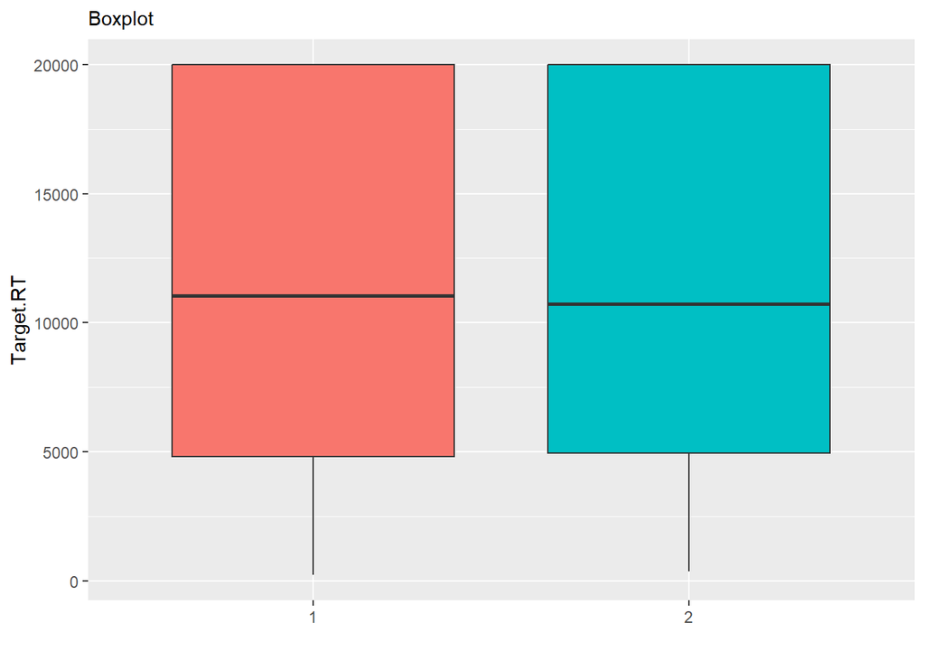

```r
# BoxPlot
part_1_with_resp %>%
  ggplot( aes(x=Condition, y=Target.RT, fill=Condition)) +
  geom_boxplot()+
  theme(
      legend.position="none",
      plot.title = element_text(size=11)
    ) +
    ggtitle("Boxplot") +
    xlab("")
```

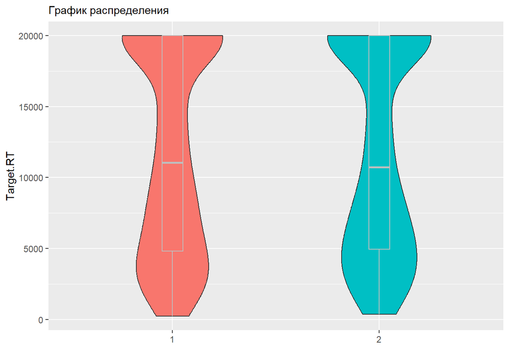

```r
# Графики распределения
part_1_with_resp %>%
  ggplot( aes(x=Condition, y=Target.RT, fill=Condition)) +
    geom_violin(width=0.5) +
    geom_boxplot(width=0.1, color="grey", alpha=0.5) +
    theme(
      legend.position="none",
      plot.title = element_text(size=11)
    ) +
    ggtitle("График распределения") +
    xlab("")
```

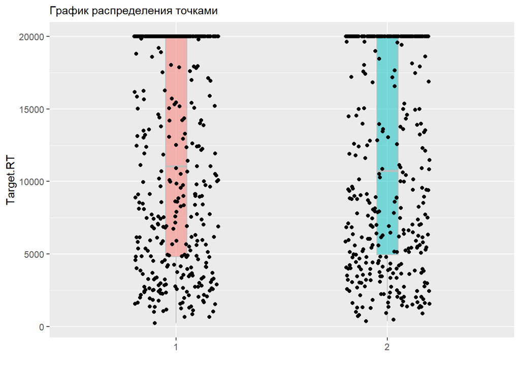

```r
part_1_with_resp %>%
  ggplot( aes(x=Condition, y=Target.RT, fill=Condition)) +
    geom_boxplot(width=0.1, color="grey", alpha=0.5) +
    geom_jitter(shape=16, position=position_jitter(0.2)) +
    theme(
        legend.position="none",
        plot.title = element_text(size=11)
      ) +
      ggtitle("График распределения точками") +
      xlab("")
```

### Время ответа только по кнопке

```r
#только решённые задачи
part_1_with_resp <- part_1 %>% filter(Target.RT != 0)

part_1_with_resp$Target.RT %>% table()
```

```
## .
##   229   361   485   658   676   716   806   855   916   937  1005  1008  1033
##     1     1     1     1     1     1     1     1     1     1     1     1     1
##  1066  1124  1166  1245  1268  1302  1309  1310  1324  1347  1349  1355  1387
##     1     1     1     1     1     1     1     1     1     1     1     1     1
##  1389  1391  1420  1470  1508  1532  1562  1575  1579  1619  1627  1639  1640
##     1     1     1     1     1     1     1     1     1     1     1     1     1
##  1659  1671  1675  1722  1783  1784  1825  1828  1876  1933  1942  1980  2004
##     1     1     1     1     1     1     1     1     1     1     1     1     1
##  2030  2031  2036  2043  2048  2059  2083  2155  2156  2180  2222  2229  2261
##     1     1     1     1     1     1     1     1     1     2     1     1     1
##  2281  2304  2327  2338  2354  2380  2392  2426  2429  2444  2445  2447  2458
##     1     1     1     1     1     1     1     1     1     1     1     1     1
##  2474  2501  2506  2516  2524  2533  2569  2581  2632  2634  2657  2677  2732
##     1     1     1     1     1     1     1     2     1     1     1     1     1
```

[output cut: 64 more lines]

```r
print('Оставшийся процент проб')
```

```
## [1] "Оставшийся процент проб"
```

```r
#Описательные статистики 1 условие
part_1_with_resp %>% filter(Condition == 1) %>% select(Target.RT) %>% summary()
```

```
##    Target.RT
##  Min.   :  229
##  1st Qu.: 3294
##  Median : 6528
##  Mean   : 7562
##  3rd Qu.:10853
##  Max.   :19827
```

```r
#Описательные статистики 2 условие
part_1_with_resp %>% filter(Condition == 2 )%>% select(Target.RT) %>% summary()
```

```
##    Target.RT
##  Min.   :  361
##  1st Qu.: 3562
##  Median : 6149
##  Mean   : 7310
##  3rd Qu.:10139
##  Max.   :19636
```

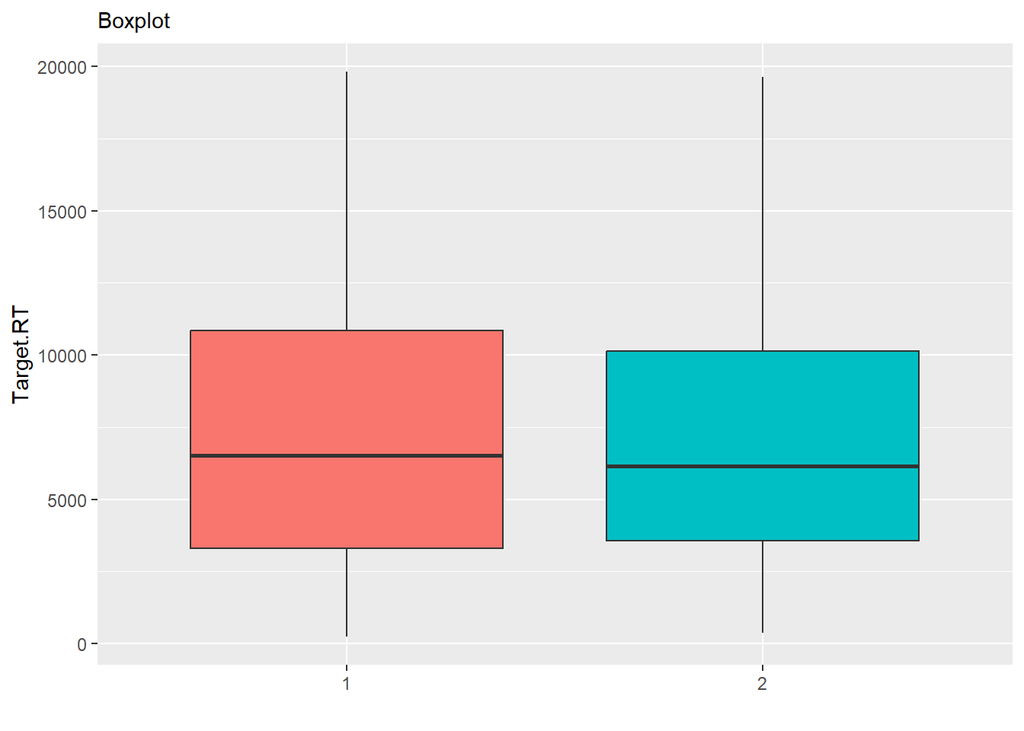

```r
# BoxPlot
part_1_with_resp %>%
  ggplot( aes(x=Condition, y=Target.RT, fill=Condition)) +
  geom_boxplot()+
  theme(
      legend.position="none",
      plot.title = element_text(size=11)
    ) +
    ggtitle("Boxplot") +
    xlab("")
```

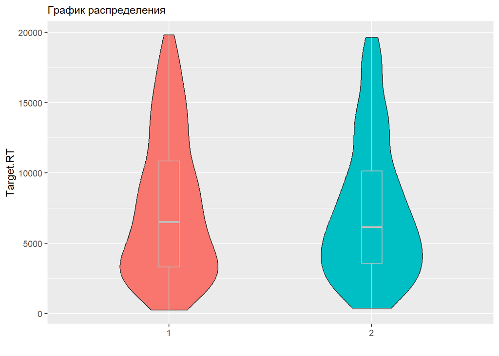

```r
# Графики распределения
part_1_with_resp %>%
  ggplot( aes(x=Condition, y=Target.RT, fill=Condition)) +
    geom_violin(width=0.5) +
    geom_boxplot(width=0.1, color="grey", alpha=0.5) +
    theme(
      legend.position="none",
      plot.title = element_text(size=11)
    ) +
    ggtitle("График распределения") +
    xlab("")
```

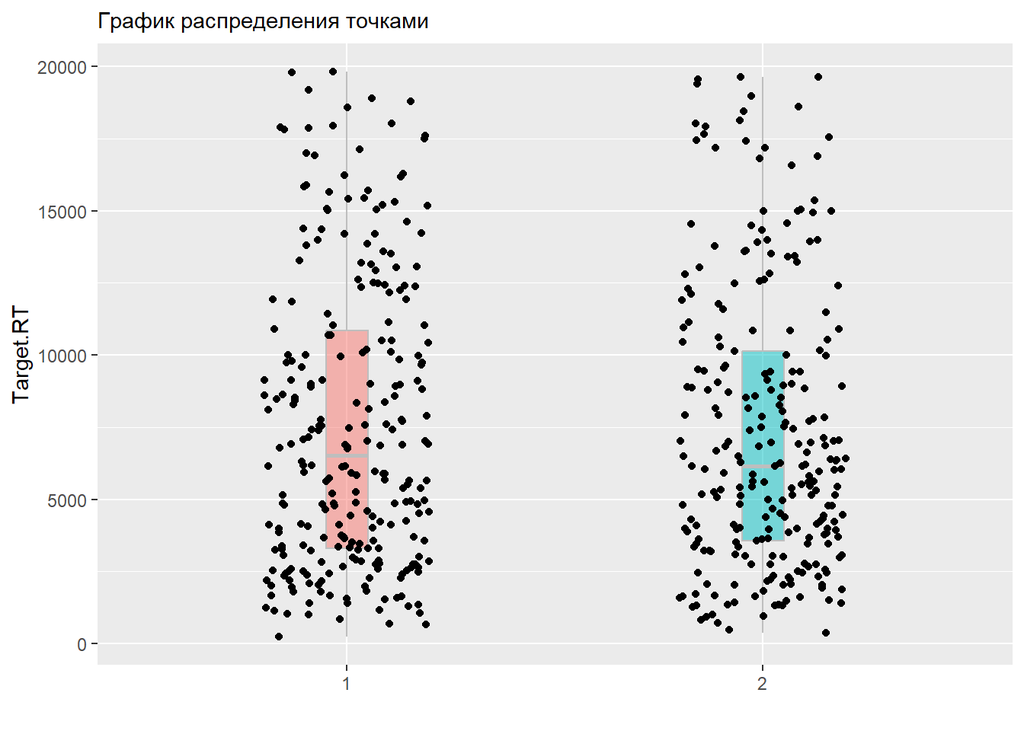

```r
part_1_with_resp %>%
  ggplot( aes(x=Condition, y=Target.RT, fill=Condition)) +
    geom_boxplot(width=0.1, color="grey", alpha=0.5) +
    geom_jitter(shape=16, position=position_jitter(0.2)) +
    theme(
        legend.position="none",
        plot.title = element_text(size=11)
      ) +
      ggtitle("График распределения точками") +
      xlab("")
```

```r
#только решённые задачи
responses$prob <- responses$`Номер_пробы_(этап_1)...2`
responses$Subject <- responses$ID %>% as.character()
part_1_with_resp <- merge(part_1, responses,  by=c("Subject","prob"))

part_1_with_resp$cor <- part_1_with_resp$`Ответ_(этап_1)`== part_1_with_resp$Anagram
part_1_with_resp <- part_1_with_resp %>% filter(cor == TRUE)

part_1_with_resp$Target.RT %>% table()
```

```
## .
##     0   229   361   485   658   676   716   806   855   916   937  1005  1008
##    17     1     1     1     1     1     1     1     1     1     1     1     1
##  1033  1066  1166  1245  1268  1302  1309  1310  1324  1347  1349  1387  1389
##     1     1     1     1     1     1     1     1     1     1     1     1     1
##  1391  1420  1470  1508  1562  1575  1579  1619  1627  1639  1640  1659  1671
##     1     1     1     1     1     1     1     1     1     1     1     1     1
##  1675  1722  1783  1784  1825  1828  1876  1933  1942  1980  2004  2030  2031
##     1     1     1     1     1     1     1     1     1     1     1     1     1
##  2036  2043  2048  2083  2155  2156  2180  2229  2261  2281  2304  2327  2338
##     1     1     1     1     1     1     2     1     1     1     1     1     1
##  2354  2380  2392  2426  2429  2444  2445  2447  2458  2474  2501  2506  2516
##     1     1     1     1     1     1     1     1     1     1     1     1     1
##  2524  2533  2569  2581  2632  2634  2657  2677  2732  2736  2747  2749  2751
##     1     1     1     2     1     1     1     1     1     1     1     1     1
```

[output cut: 54 more lines]

```r
print('Оставшийся процент проб')
```

```
## [1] "Оставшийся процент проб"
```

```r
#Описательные статистики 1 условие
part_1_with_resp %>% filter(Condition == 1) %>% select(Target.RT) %>% summary()
```

```
##    Target.RT
##  Min.   :    0
##  1st Qu.: 2778
##  Median : 5629
##  Mean   : 6646
##  3rd Qu.: 9649
##  Max.   :19827
```

```r
#Описательные статистики 2 условие
part_1_with_resp %>% filter(Condition == 2 )%>% select(Target.RT) %>% summary()
```

```
##    Target.RT
##  Min.   :    0
##  1st Qu.: 3082
##  Median : 5584
##  Mean   : 6605
##  3rd Qu.: 8930
##  Max.   :19636
```

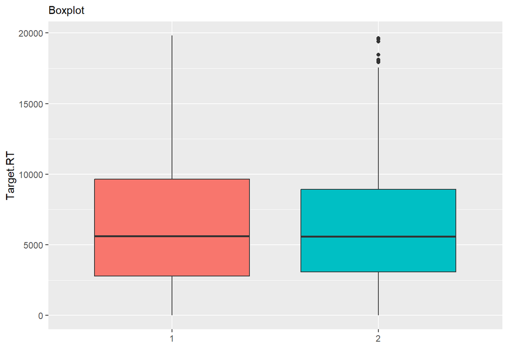

```r
# BoxPlot
part_1_with_resp %>%
  ggplot( aes(x=Condition, y=Target.RT, fill=Condition)) +
  geom_boxplot()+
  theme(
      legend.position="none",
      plot.title = element_text(size=11)
    ) +
    ggtitle("Boxplot") +
    xlab("")
```

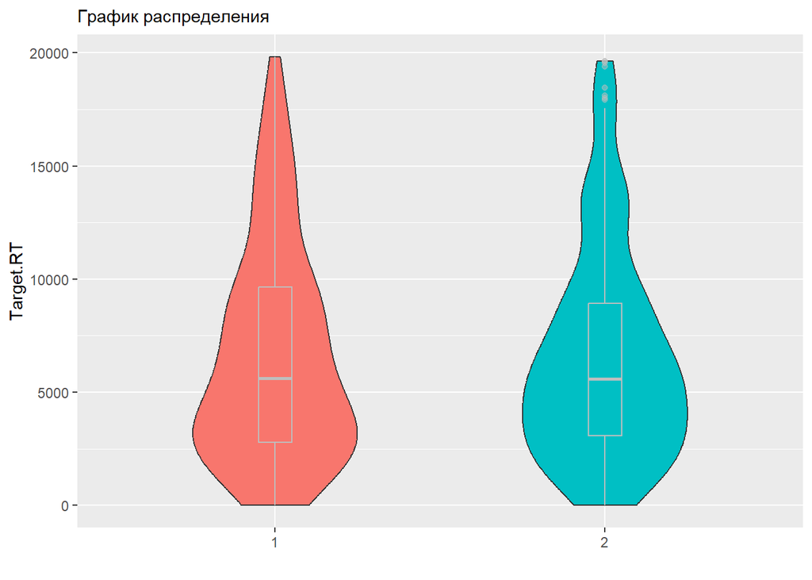

```r
# Графики распределения
part_1_with_resp %>%
  ggplot( aes(x=Condition, y=Target.RT, fill=Condition)) +
    geom_violin(width=0.5) +
    geom_boxplot(width=0.1, color="grey", alpha=0.5) +
    theme(
      legend.position="none",
      plot.title = element_text(size=11)
    ) +
    ggtitle("График распределения") +
    xlab("")
```

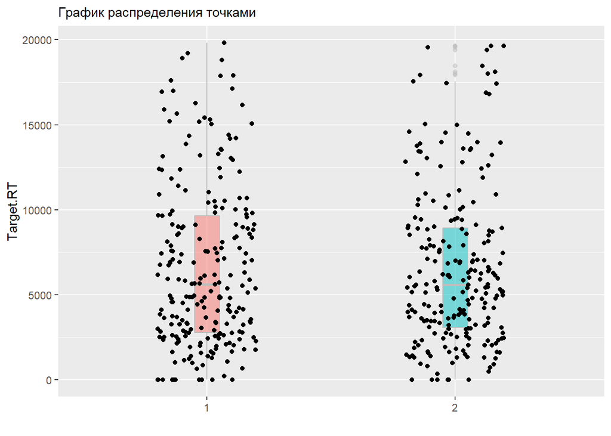

```r
part_1_with_resp %>%
  ggplot( aes(x=Condition, y=Target.RT, fill=Condition)) +
    geom_boxplot(width=0.1, color="grey", alpha=0.5) +
    geom_jitter(shape=16, position=position_jitter(0.2)) +
    theme(
        legend.position="none",
        plot.title = element_text(size=11)
      ) +
      ggtitle("График распределения точками") +
      xlab("")
```

## Правильность ответов

```r
responses$prob <- responses$`Номер_пробы_(этап_1)...2`
responses$Subject <- responses$ID %>% as.character()
df_corr <- merge(part_1, responses,  by=c("Subject","prob"))
df_corr$correct <- (df_corr$Anagram == df_corr$`Ответ_(этап_1)`) %>% as.numeric()
df_corr$correct %>% table()
```

```
## .
##   0   1
## 316 464
```

```r
df_corr %>% View()

responses$Subject %>% table()
```

```
## .
##  1 10  2  3  4  5  6  7  8  9
## 78 78 78 78 78 78 78 78 78 78
```

```r
df_corr_mn <- df_corr %>%
                    group_by(Subject, Condition) %>%
                    summarise(correct_per = sum(correct, na.rm = TRUE))
# таблица процента правильных ответов
df_corr_mn %>% select(Subject, Condition, correct_per)
```

```
## # A tibble: 20 × 3
## # Groups:   Subject [10]
##    Subject Condition correct_per
##    <fct>   <chr>           <dbl>
##  1 1       1                  17
##  2 1       2                  21
##  3 10      1                  22
##  4 10      2                  17
##  5 2       1                  31
##  6 2       2                  31
##  7 3       1                  29
##  8 3       2                  24
##  9 4       1                  20
## 10 4       2                  20
## 11 5       1                  22
## 12 5       2                  22
## 13 6       1                  24
## 14 6       2                  25
## 15 7       1                  17
## 16 7       2                  17
## 17 8       1                  35
## 18 8       2                  31
## 19 9       1                  16
## 20 9       2                  23
```

```r
# описательная статистика
df_corr_mn %>% filter(Condition == 1) %>% select(correct_per) %>%  summary()
```

```
##     Subject   correct_per
##  1      :1   Min.   :16.00
##  10     :1   1st Qu.:17.75
##  2      :1   Median :22.00
##  3      :1   Mean   :23.30
##  4      :1   3rd Qu.:27.75
##  5      :1   Max.   :35.00
##  (Other):4
```

```r
df_corr_mn %>% filter(Condition == 2) %>% select(correct_per) %>%  summary()
```

```
##     Subject   correct_per
##  1      :1   Min.   :17.00
##  10     :1   1st Qu.:20.25
##  2      :1   Median :22.50
##  3      :1   Mean   :23.10
##  4      :1   3rd Qu.:24.75
##  5      :1   Max.   :31.00
##  (Other):4
```

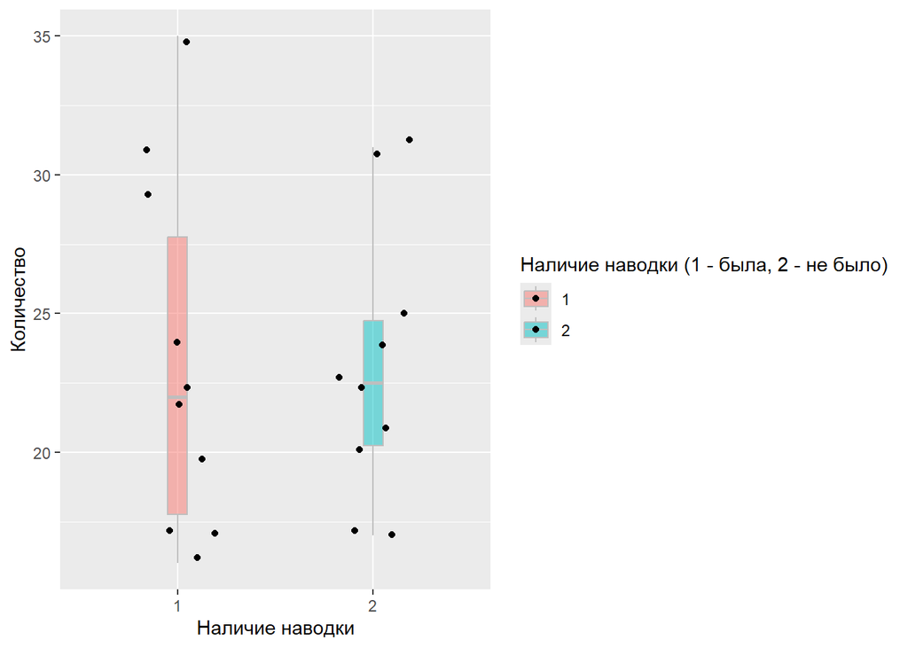

```r
df_corr_mn %>%
  ggplot( aes(x=Condition, y=correct_per, fill=Condition)) +
    geom_boxplot(width=0.1, color="grey", alpha=0.5) +
    geom_jitter(shape=16, position=position_jitter(0.2)) +
    labs (x = "Наличие наводки", y = "Количество", fill ="Наличие наводки (1 - была, 2 - не было)")
```

Снижения точности в связи с фиксацией увидеть достаточно сложно.

# Гипотеза 2

Решение анаграмм с активной наводкой будет чаще сопровождаться Ага!-переживанием, чем решение анаграмм без наводки.

```r
part_1$Q1Aha.RESP <- part_1$Q1Aha.RESP %>% as.factor()
part_1 %>% filter(Condition == 1) %>% select(Q1Aha.RESP) %>% table()
```

```
## Q1Aha.RESP
##   1   2   3
## 147 102 141
```

```r
part_1 %>% filter(Condition == 2) %>% select(Q1Aha.RESP) %>% table()
```

```
## Q1Aha.RESP
##   1   2   3
## 121 124 145
```

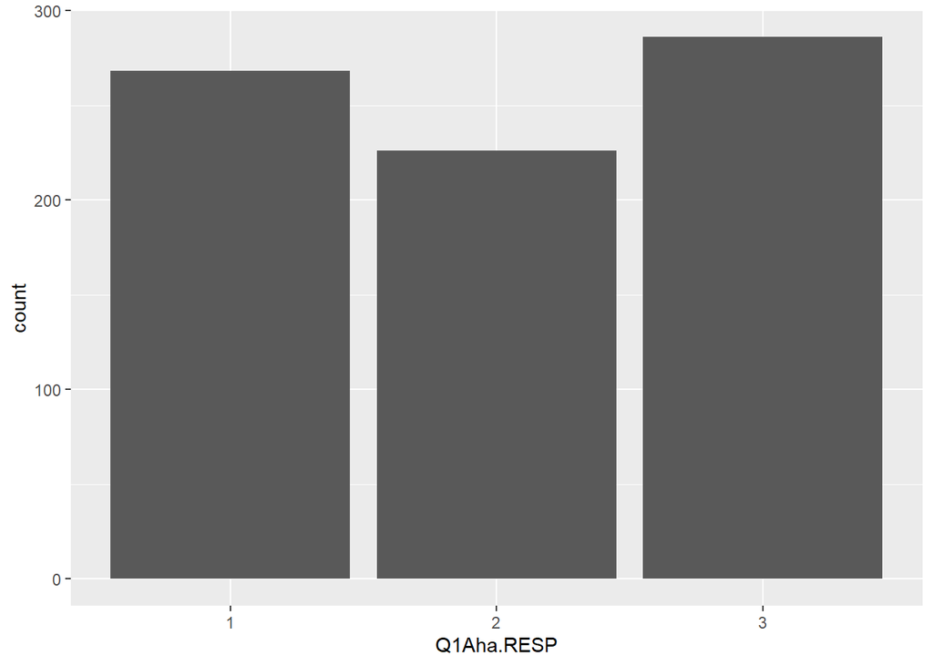

```r
part_1 %>% ggplot(aes(Q1Aha.RESP))+
  geom_bar()
```

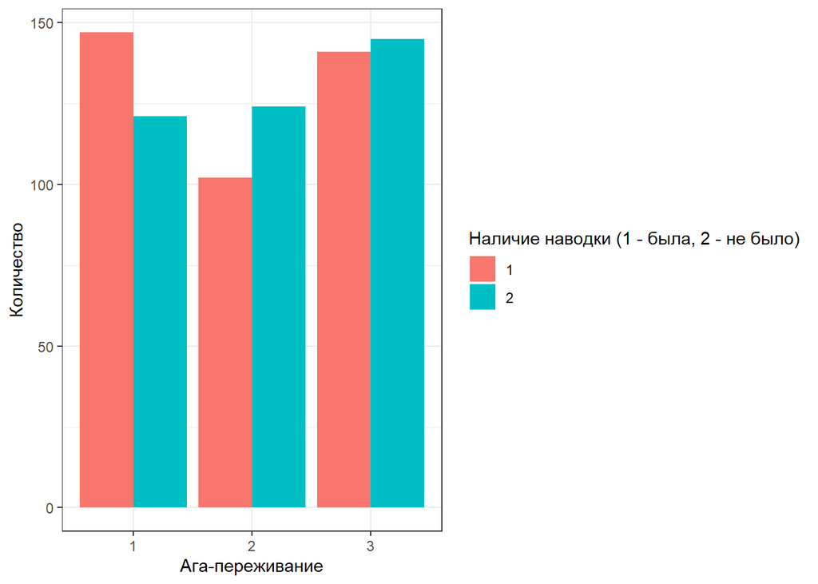

```r
# Аганшность + фиксация
# В качестве переменной y - количество, т.е. количество проб, где лйуди ставили 1 по агашности, с фиксацией и без фиксации
part_1 %>% ggplot(aes(x = Q1Aha.RESP, fill = Condition)) +
        geom_bar(position = "dodge")+
        labs (x = "Ага-переживание", y = "Количество", fill ="Наличие наводки (1 - была, 2 - не было)")+
        theme_bw()
```

# Загрузка данных 2го этапа

```r
# первый
data_path <- 'data/2_part/'
load_file_2 <- function(x) {
  if (str_detect(x, 'csv')) {
    df <- read_csv(str_c(data_path, x),
                   col_types = cols(.default = col_character()))
    bio <- df %>% filter(sender == "Анкета")
    df$age <- bio$age
    df$id <- bio$id
    df$sex <- bio$sex
    df$group <- bio$группа

    versions <- df %>% filter(sender == "Версии *код")
    anagram <- df %>% filter(sender == "Анаграмма *код")
    df <- df %>% filter(sender == "Ответ *код")
    df$duration <-  anagram$duration
    df$ended_on <- anagram$ended_on

    df$version_audio <- versions$audio

    df <- df %>% select(-sender_type, -timestamp, -url, -meta, -группа)
    df <- df %>% filter(df_RUN != 'Run0')

    block <- 26 * (df$i %>% as.numeric() -1 )
    df$prob <- (df$counter %>% as.numeric() + 1) + block

    df$duration <- df$duration %>% as.numeric()
    df$df_Condition <- df$df_Condition %>% as.factor()
    return(df)

  }
}

part_2 <- do.call('bind_rows',
                 data_path %>%
                   list.files() %>%
                   lapply(load_file_2))
part_2 %>%
  select(id, i, prob) %>%
  View()
```

# Гипотеза 3

На втором этапе (через сутки) повторное решение анаграмм, решенных ранее на первом этапе, будет значимо быстрее, чем нерешенных. Этот мнемический выигрыш будет больше для анаграмм с активной наводкой и для анаграмм, решенных на первом этапе с Ага, – гипотеза мнемического преимущества инсайта

```r
# подготовка для соединения
part_2$Subject <- part_2$id
part_2$Anagram <- part_2$df_анаграмма
part_2$prob_2 <- part_2$prob

# содеенинеие таблица
df_all = merge(df_corr, part_2, by=c("Subject","Anagram"))

# подготовка для соединения
df_all <- df_all %>% select(-`Ответ_(этап_2)`, -`Версии_(этап_2)`, -`Номер_пробы_(этап_1)...6`, -`Блок_(этап_2)`)
part_2_resp <- responses %>% select(Subject, `Ответ_(этап_2)`, `Версии_(этап_2)`, prob, `Блок_(этап_2)`)
part_2_resp$prob_2 <- part_2_resp$prob
part_2_resp <- part_2_resp %>% select(-prob)

# содеенинеие таблица
df_all <- merge(df_all, part_2_resp, by=c("Subject", "prob_2"))

# убрать пробы, которые не отображались по техническим причинам
df_all <- df_all %>% filter(!is.na(`Ответ_(этап_2)`))
df_all <- df_all %>% select(-audio, -version_audio)


df_corr$Subject %>% table()
```

```
## .
##  1 10  2  3  4  5  6  7  8  9
## 78 78 78 78 78 78 78 78 78 78
```

```r
df_only_corr <- df_all %>% filter(`Ответ_(этап_2)` == Anagram)
```

Количество проб решённых на 1 этапе и решённых на 2 этапе

```r
df_all %>% filter(`Ответ_(этап_1)` == Anagram) %>% nrow()
```

```
## [1] 371
```

```r
df_all %>% filter(`Ответ_(этап_2)` == Anagram) %>% nrow()
```

```
## [1] 377
```

```r
#write_csv(df_all, 'all_merge.csv')



df_all_corr <- df_all %>% filter(`Ответ_(этап_1)` == Anagram & `Ответ_(этап_2)` == Anagram)
df_all_corr %>% nrow() / df_all %>% nrow()
```

```
## [1] 0.4647436
```

```r
df_all_corr[df_all_corr$Target.RT == 0, ]$Target.RT = 20000

df_all_corr$duration_1 <- df_all_corr$Target.RT + (df_all_corr$Cue.OnsetToOnsetTime %>% as.numeric())
df_all_corr$duration_2 <- df_all_corr$duration


df_all_corr_1 <- df_all_corr
df_all_corr_1$duration <- df_all_corr_1$duration_1
df_all_corr_1$stage <- 1
df_all_corr_1 <- df_all_corr_1 %>% select(Subject, Condition, duration, stage)

df_all_corr_2 <- df_all_corr
df_all_corr_2$duration <- df_all_corr_2$duration_2
df_all_corr_2$stage <- 2
df_all_corr_2 <- df_all_corr_2 %>% select(Subject, Condition, duration, stage)
df_all_corr_2 %>% nrow()
```

```
## [1] 290
```

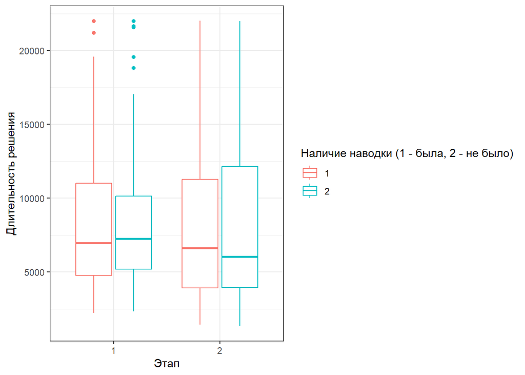

```r
df_all_corr_3 <- rbind(df_all_corr_1, df_all_corr_2)
df_all_corr_3$stage <- df_all_corr_3$stage %>% as.factor()

df_all_corr_3 %>% ggplot(aes(stage, duration, color = Condition))+
  geom_boxplot()+
  labs (x = "Этап", y = "Длительность решения", color ="Наличие наводки (1 - была, 2 - не было)")+
  theme_bw()
```

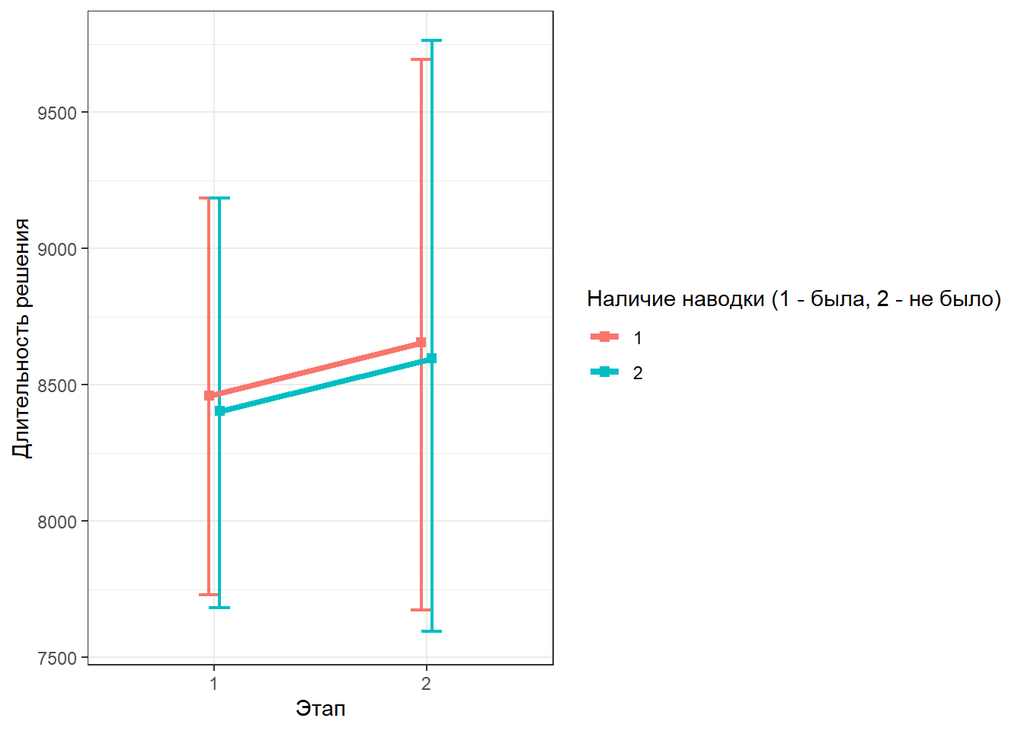

```r
pd = position_dodge(0.1)

df_all_corr_3 %>% ggplot(aes(x = stage, y = duration, color = Condition, group = Condition)) +
  stat_summary(fun.data = mean_cl_boot, geom = 'errorbar', width = 0.2, lwd = 0.8, position = pd)+
  stat_summary(fun.data = mean_cl_boot, geom = 'line', size = 1.5, position = pd) +
  stat_summary(fun.data = mean_cl_boot, geom = 'point', size = 2, position = pd, pch=15) +
  labs (x = "Этап", y = "Длительность решения", color ="Наличие наводки (1 - была, 2 - не было)")+
  theme_bw()
```

Чуть больше анаграмм решили на втором этапе.

Сравнение количества проб решённых по отношенийу ко всем”

```r
data_path <- 'data/1_part/'
part_1 <- data.frame()
part_1 <- do.call('bind_rows',
                 data_path %>%
                   list.files() %>%
                   lapply(load_file_1)
)
part_1 <- part_1 %>% filter(!is.na(ProbesList))

part_1$char_count <- nchar(part_1$Anagram)
part_1$char_count <- part_1$char_count %>% as.factor()


part_1$preactiave <- 0
part_1[part_1$Subject == 3,]$preactiave <- 1
part_1[part_1$Subject == 5,]$preactiave <- 1
part_1[part_1$Subject == 6,]$preactiave <- 1
part_1[part_1$Subject == 7,]$preactiave <- 1
part_1[part_1$Subject == 9,]$preactiave <- 1
part_1$preactiave <- part_1$preactiave %>% as.factor()


responses$prob <- responses$`Номер_пробы_(этап_1)...2`
responses$Subject <- responses$ID %>% as.character()
part_1_with_resp <- merge(part_1, responses,  by=c("Subject","prob"))

part_1_with_resp$cor <- part_1_with_resp$`Ответ_(этап_1)`== part_1_with_resp$Anagram
part_1_with_resp_1 <- part_1_with_resp
part_1_with_resp <- part_1_with_resp %>% filter(cor == TRUE)

part_1_with_resp$Target.RT %>% table()
```

```
## .
##     0   229   361   485   658   676   716   806   855   916   937  1005  1008
##    17     1     1     1     1     1     1     1     1     1     1     1     1
##  1033  1066  1166  1245  1268  1302  1309  1310  1324  1347  1349  1387  1389
##     1     1     1     1     1     1     1     1     1     1     1     1     1
##  1391  1420  1470  1508  1562  1575  1579  1619  1627  1639  1640  1659  1671
##     1     1     1     1     1     1     1     1     1     1     1     1     1
##  1675  1722  1783  1784  1825  1828  1876  1933  1942  1980  2004  2030  2031
##     1     1     1     1     1     1     1     1     1     1     1     1     1
##  2036  2043  2048  2083  2155  2156  2180  2229  2261  2281  2304  2327  2338
##     1     1     1     1     1     1     2     1     1     1     1     1     1
##  2354  2380  2392  2426  2429  2444  2445  2447  2458  2474  2501  2506  2516
##     1     1     1     1     1     1     1     1     1     1     1     1     1
##  2524  2533  2569  2581  2632  2634  2657  2677  2732  2736  2747  2749  2751
##     1     1     1     2     1     1     1     1     1     1     1     1     1
```

[output cut: 54 more lines]

```r
#Описательные статистики 1 условие
part_1_with_resp %>% filter(preactiave == 0 & Condition == 1) %>% select(Target.RT) %>% summary()
```

```
##    Target.RT
##  Min.   :    0
##  1st Qu.: 2657
##  Median : 4638
##  Mean   : 6128
##  3rd Qu.: 9010
##  Max.   :18806
```

```r
#Описательные статистики 2 условие
part_1_with_resp %>% filter(preactiave == 0 & Condition == 2 )%>% select(Target.RT) %>% summary()
```

```
##    Target.RT
##  Min.   :    0
##  1st Qu.: 2766
##  Median : 4937
##  Mean   : 5936
##  3rd Qu.: 7881
##  Max.   :19636
```

```r
#Описательные статистики 1 условие
part_1_with_resp %>% filter(preactiave == 1 & Condition == 1) %>% select(Target.RT) %>% summary()
```

```
##    Target.RT
##  Min.   :    0
##  1st Qu.: 3258
##  Median : 6158
##  Mean   : 7247
##  3rd Qu.:10688
##  Max.   :19827
```

```r
#Описательные статистики 2 условие
part_1_with_resp %>% filter(preactiave == 1 & Condition == 2 )%>% select(Target.RT) %>% summary()
```

```
##    Target.RT
##  Min.   :    0
##  1st Qu.: 3676
##  Median : 6386
##  Mean   : 7328
##  3rd Qu.:10074
##  Max.   :19631
```

### График доля правильных ответов

```r
df_corr_mn <- part_1_with_resp_1 %>%
                    group_by(Subject, Condition, preactiave) %>%
                    summarise(correct_per = sum(cor, na.rm = FALSE))
# таблица процента правильных ответов
df_corr_mn %>% select(Subject, Condition, correct_per)
```

```
## # A tibble: 20 × 3
## # Groups:   Subject, Condition [20]
##    Subject Condition correct_per
##    <fct>   <chr>           <int>
##  1 1       1                  17
##  2 1       2                  21
##  3 10      1                  22
##  4 10      2                  17
##  5 2       1                  31
##  6 2       2                  31
##  7 3       1                  29
##  8 3       2                  24
##  9 4       1                  20
## 10 4       2                  20
## 11 5       1                  22
## 12 5       2                  22
## 13 6       1                  24
## 14 6       2                  25
## 15 7       1                  17
## 16 7       2                  17
## 17 8       1                  35
## 18 8       2                  31
## 19 9       1                  16
## 20 9       2                  23
```

```r
df_corr_mn$correct_per <- df_corr_mn$correct_per / 78
# описательная статистика
df_corr_mn %>% filter(Condition == 1) %>% select(correct_per) %>%  summary()
```

```
##     Subject   Condition          correct_per
##  1      :1   Length:10          Min.   :0.2051
##  10     :1   Class :character   1st Qu.:0.2276
##  2      :1   Mode  :character   Median :0.2821
##  3      :1                      Mean   :0.2987
##  4      :1                      3rd Qu.:0.3558
##  5      :1                      Max.   :0.4487
##  (Other):4
```

```r
df_corr_mn %>% filter(Condition == 2) %>% select(correct_per) %>%  summary()
```

```
##     Subject   Condition          correct_per
##  1      :1   Length:10          Min.   :0.2179
##  10     :1   Class :character   1st Qu.:0.2596
##  2      :1   Mode  :character   Median :0.2885
##  3      :1                      Mean   :0.2962
##  4      :1                      3rd Qu.:0.3173
##  5      :1                      Max.   :0.3974
##  (Other):4
```

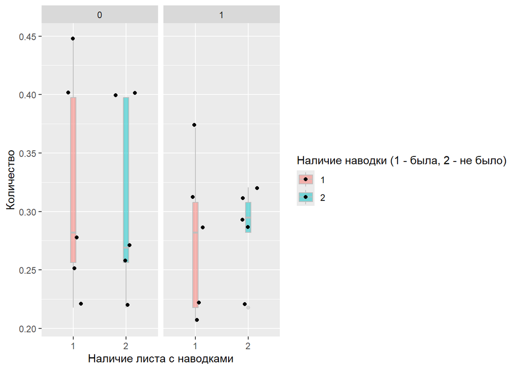

```r
df_corr_mn %>%
  ggplot( aes(x=Condition, y=correct_per, fill=Condition)) +
    geom_boxplot(width=0.1, color="grey", alpha=0.5) +
    geom_jitter(shape=16, position=position_jitter(0.2)) +
    facet_wrap(~preactiave)+
    labs (x = "Наличие листа с наводками", y = "Количество", fill ="Наличие наводки (1 - была, 2 - не было)")
```

### График времени ответа для правильно решённых анаграмм, 1 2 это condition, 0 1 это нет или есть листк с наводками

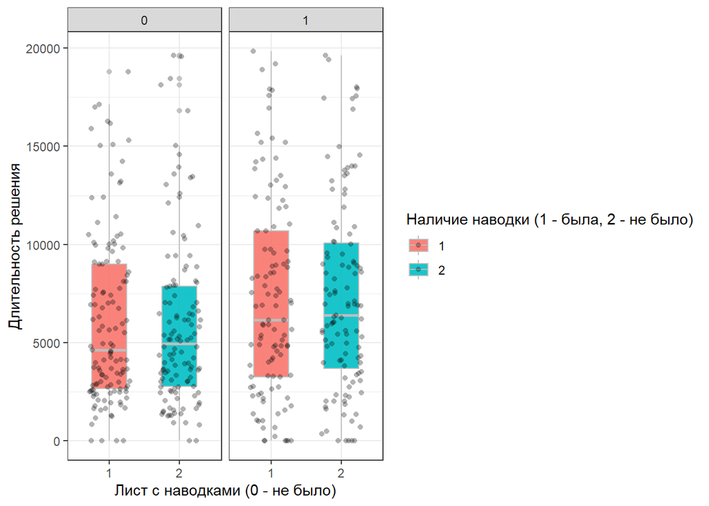

```r
part_1_with_resp %>%
  ggplot( aes(x=Condition, y=Target.RT, fill=Condition)) +
    geom_boxplot(width=0.5, color="grey", alpha=0.9) +
    geom_jitter(shape=16, position=position_jitter(0.3), alpha = 0.3) +
    facet_wrap(~preactiave)+
      labs (x = "Лист с наводками (0 - не было)", y = "Длительность решения", fill ="Наличие наводки (1 - была, 2 - не было)")+
    theme_bw()
```

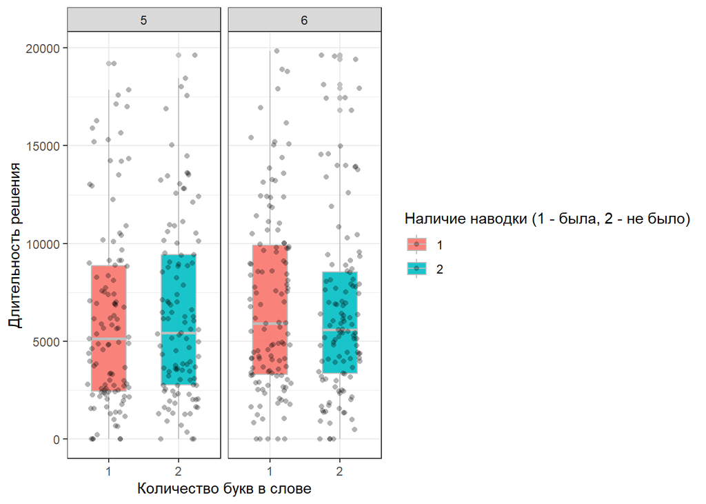

```r
part_1_with_resp %>%
  ggplot( aes(x=Condition, y=Target.RT, fill=Condition)) +
    geom_boxplot(width=0.5, color="grey", alpha=0.9) +
    geom_jitter(shape=16, position=position_jitter(0.3), alpha = 0.3) +
    facet_wrap(~char_count)+
      labs (x = "Количество букв в слове", y = "Длительность решения", fill ="Наличие наводки (1 - была, 2 - не было)")+
    theme_bw()
```

### График времени ответа для правильно решённых анаграмм, Фиксированность + количество букв + наличие листа с наводками

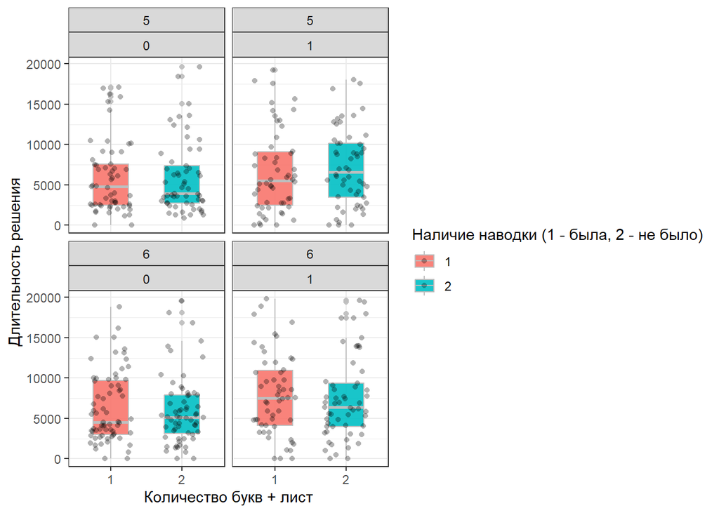

```r
part_1_with_resp %>%
  ggplot( aes(x=Condition, y=Target.RT, fill=Condition)) +
    geom_boxplot(width=0.5, color="grey", alpha=0.9) +
    geom_jitter(shape=16, position=position_jitter(0.3), alpha = 0.3) +
    facet_wrap(~char_count+preactiave)+
      labs (x = "Количество букв + лист", y = "Длительность решения", fill ="Наличие наводки (1 - была, 2 - не было)")+
    theme_bw()
```

Больше всего эффект фиксированности, когда лист + 6 буквенные.

### Количество Ага-ответов

```r
part_1$Q1Aha.RESP <- part_1$Q1Aha.RESP %>% as.factor()
```

### График количества Ага, по наличию листа

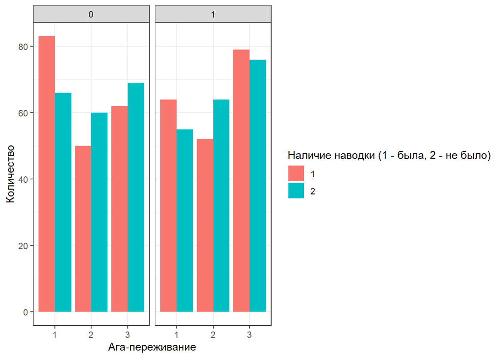

```r
# Аганшность + фиксация
# В качестве переменной y - количество, т.е. количество проб, где лйуди ставили 1 по агашности, с фиксацией и без фиксации
part_1 %>% ggplot(aes(x = Q1Aha.RESP, fill = Condition)) +
        geom_bar(position = "dodge")+
        labs (x = "Ага-переживание", y = "Количество", fill ="Наличие наводки (1 - была, 2 - не было)")+
        facet_wrap(~preactiave)+
        theme_bw()
```

### График количества Ага, по количеству букв

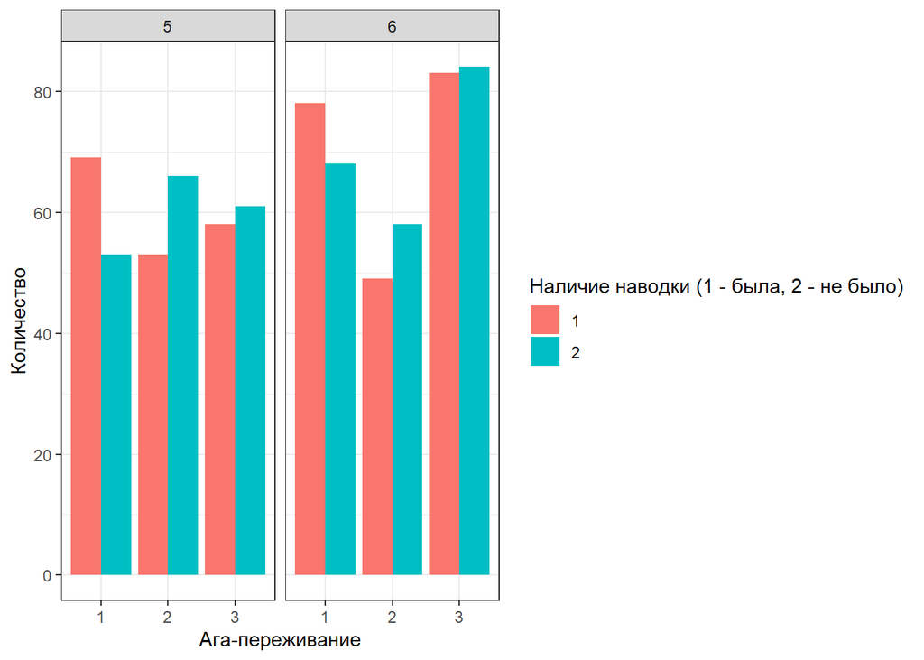

```r
part_1 %>% ggplot(aes(x = Q1Aha.RESP, fill = Condition)) +
        geom_bar(position = "dodge")+
        labs (x = "Ага-переживание", y = "Количество", fill ="Наличие наводки (1 - была, 2 - не было)")+
        facet_wrap(~char_count)+
        theme_bw()
```

Среди 6 буквенных

```r
part_1$Q1Aha.RESP <- part_1$Q1Aha.RESP %>% as.factor()

part_1$Condition <- part_1$Condition %>% as.factor()

part_1 %>%
  group_by(Subject, Condition, preactiave) %>%
  summarise(Aha = sum(Q1Aha.RESP == 1), NotAha = sum(Q1Aha.RESP == 2 | Q1Aha.RESP == 3)) -> part_1_aha_group
part_1_aha_group$Aha_percent <- part_1_aha_group$Aha / (part_1_aha_group$Aha + part_1_aha_group$NotAha)
```

### Графики с долей ага-переживаний

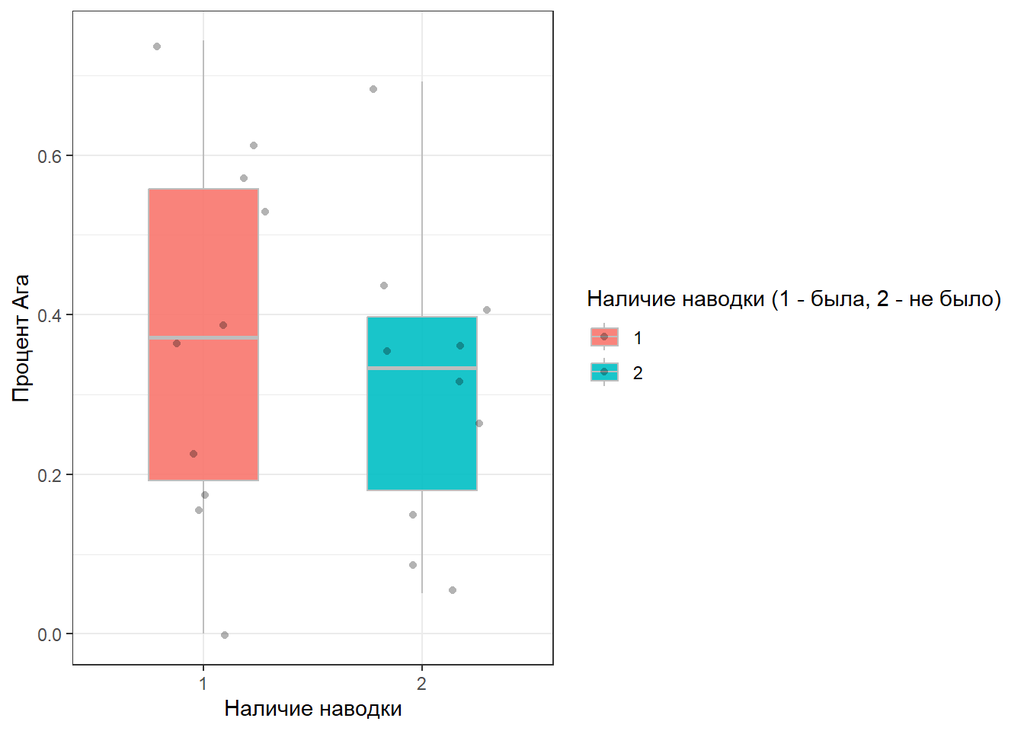

```r
part_1_aha_group %>% ggplot(aes(x = Condition, y = Aha_percent, fill = Condition)) +
    geom_boxplot(width=0.5, color="grey", alpha=0.9) +
    geom_jitter(shape=16, position=position_jitter(0.3), alpha = 0.3) +
      labs (x = "Наличие наводки", y = "Процент Ага", fill ="Наличие наводки (1 - была, 2 - не было)")+
    theme_bw()
```

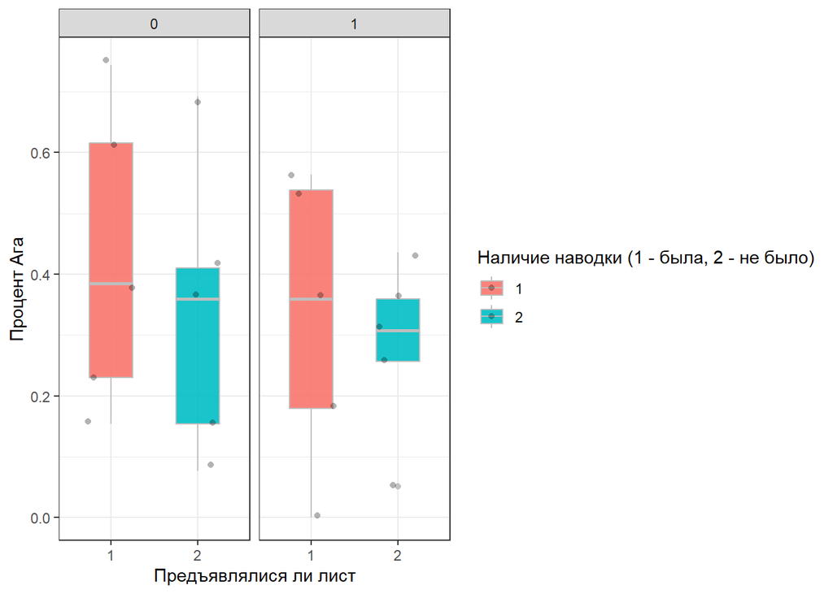

```r
part_1_aha_group %>% ggplot(aes(x = Condition, y = Aha_percent, fill = Condition)) +
    geom_boxplot(width=0.5, color="grey", alpha=0.9) +
    geom_jitter(shape=16, position=position_jitter(0.3), alpha = 0.3) +
    facet_wrap(~preactiave)+
      labs (x = "Предъявлялися ли лист", y = "Процент Ага", fill ="Наличие наводки (1 - была, 2 - не было)")+
    theme_bw()
```

Как будто не зависит от лица.

```r
data_path <- 'data/2_part/'

part_2 <- do.call('bind_rows',
                 data_path %>%
                   list.files() %>%
                   lapply(load_file_2))


# подготовка для соединения
part_2$Subject <- part_2$id
part_2$Anagram <- part_2$df_анаграмма
part_2$prob_2 <- part_2$prob
part_2$id %>% table()
```

```
## .
##  1 10  2  3  4  7  8  9
## 78 78 78 78 78 78 78 78
```

```r
# содеенинеие таблица
df_all = merge(part_1_with_resp_1, part_2, by=c("Subject","Anagram"))


# подготовка для соединения
df_all <- df_all %>% select(-`Ответ_(этап_2)`, -`Версии_(этап_2)`, -`Номер_пробы_(этап_1)...6`, -`Блок_(этап_2)`)
part_2_resp <- responses %>% select(Subject, `Ответ_(этап_2)`, `Версии_(этап_2)`, prob, `Блок_(этап_2)`)
part_2_resp$prob_2 <- part_2_resp$prob
part_2_resp <- part_2_resp %>% select(-prob)

# содеенинеие таблица
df_all <- merge(df_all, part_2_resp, by=c("Subject", "prob_2"))

# убрать пробы, которые не отображались по техническим причинам
df_all <- df_all %>% filter(!is.na(`Ответ_(этап_2)`))
df_all <- df_all %>% select(-audio, -version_audio)
df_all <- df_all %>% filter(Subject != 5)
df_all <- df_all %>% filter(Subject != 6)
df_all %>% View()


df_all_corr <- df_all %>% filter(`Ответ_(этап_1)` == Anagram & `Ответ_(этап_2)` == Anagram)


df_all_corr[df_all_corr$Target.RT == 0, ]$Target.RT = 20000

df_all_corr$duration_1 <- df_all_corr$Target.RT + (df_all_corr$Cue.OnsetToOnsetTime %>% as.numeric())
df_all_corr$duration_2 <- df_all_corr$duration


df_all_corr_1 <- df_all_corr
df_all_corr_1$duration <- df_all_corr_1$duration_1
df_all_corr_1$stage <- 1
df_all_corr_1 <- df_all_corr_1 %>% select(Subject, Condition, duration, stage, preactiave, char_count)

df_all_corr_2 <- df_all_corr
df_all_corr_2$duration <- df_all_corr_2$duration_2
df_all_corr_2$stage <- 2
df_all_corr_2 <- df_all_corr_2 %>% select(Subject, Condition, duration, stage, preactiave, char_count)
df_all_corr_2 %>% nrow()
```

```
## [1] 290
```

```r
df_all_corr_3 <- rbind(df_all_corr_1, df_all_corr_2)
df_all_corr_3$stage <- df_all_corr_3$stage %>% as.factor()
df_all_corr_3$duration %>% summary()
```

```
##    Min. 1st Qu.  Median    Mean 3rd Qu.    Max.
##    1353    4461    6906    8530   11115   22015
```

### Сравнение времени решения на первом этапе и втором этапе, с разделениями на фиксированность, количество букв в анаграмме, предъявления листа

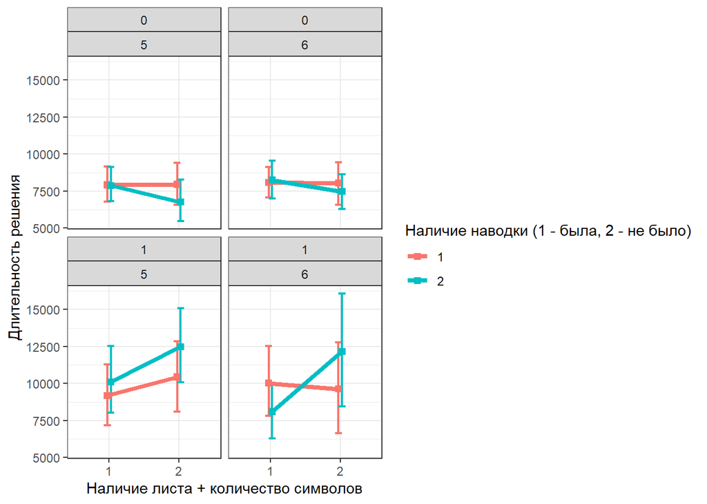

```r
pd = position_dodge(0.1)
df_all_corr_3 %>% ggplot(aes(x = stage, y = duration, color = Condition, group = Condition)) +
  stat_summary(fun.data = mean_cl_boot, geom = 'errorbar', width = 0.2, lwd = 0.8, position = pd)+
  stat_summary(fun.data = mean_cl_boot, geom = 'line', size = 1.5, position = pd) +
  stat_summary(fun.data = mean_cl_boot, geom = 'point', size = 2, position = pd, pch=15) +
  facet_wrap(~preactiave+char_count)+
  labs (x = "Наличие листа + количество символов", y = "Длительность решения", color ="Наличие наводки (1 - была, 2 - не было)")+
  theme_bw()
```